# W3cubDocs

/scikit-learn

# 3.2.4.3.3. sklearn.ensemble.ExtraTreesClassifier

**`class sklearn.ensemble.ExtraTreesClassifier(n_estimators=’warn’, criterion=’gini’, max_depth=None, min_samples_split=2, min_samples_leaf=1, min_weight_fraction_leaf=0.0, max_features=’auto’, max_leaf_nodes=None, min_impurity_decrease=0.0, min_impurity_split=None, bootstrap=False, oob_score=False, n_jobs=None, random_state=None, verbose=0, warm_start=False, class_weight=None)` [[source]](https://github.com/scikit-learn/scikit-learn/blob/bac89c2/sklearn/ensemble/forest.py#L1294)**

An extra-trees classifier.

This class implements a meta estimator that fits a number of randomized decision trees (a.k.a. extra-trees) on various sub-samples of the dataset and uses averaging to improve the predictive accuracy and control over-fitting.

Read more in the User Guide.

Parameters:

**`n_estimators : integer, optional (default=10)`**

The number of trees in the forest.

Changed in version 0.20: The default value of `n_estimators` will change from 10 in version 0.20 to 100 in version 0.22.

**`criterion : string, optional (default=”gini”)`**

The function to measure the quality of a split. Supported criteria are “gini” for the Gini impurity and “entropy” for the information gain.

**`max_depth : integer or None, optional (default=None)`**

The maximum depth of the tree. If None, then nodes are expanded until all leaves are pure or until all leaves contain less than min_samples_split samples.

**`min_samples_split : int, float, optional (default=2)`**

The minimum number of samples required to split an internal node:

- If int, then consider `min_samples_split` as the minimum number.
- If float, then `min_samples_split` is a fraction and `ceil(min_samples_split * n_samples)` are the minimum number of samples for each split.

Changed in version 0.18: Added float values for fractions.

**`min_samples_leaf : int, float, optional (default=1)`**

The minimum number of samples required to be at a leaf node. A split point at any depth will only be considered if it leaves at least `min_samples_leaf` training samples in each of the left and right branches. This may have the effect of smoothing the model, especially in regression.

- If int, then consider `min_samples_leaf` as the minimum number.
- If float, then `min_samples_leaf` is a fraction and `ceil(min_samples_leaf * n_samples)` are the minimum number of samples for each node.

Changed in version 0.18: Added float values for fractions.

**`min_weight_fraction_leaf : float, optional (default=0.)`**

The minimum weighted fraction of the sum total of weights (of all the input samples) required to be at a leaf node. Samples have equal weight when sample_weight is not provided.

**`max_features : int, float, string or None, optional (default=”auto”)`**

The number of features to consider when looking for the best split:

- If int, then consider `max_features` features at each split.
- If float, then `max_features` is a fraction and `int(max_features * n_features)` features are considered at each split.
- If “auto”, then `max_features=sqrt(n_features)`.
- If “sqrt”, then `max_features=sqrt(n_features)`.
- If “log2”, then `max_features=log2(n_features)`.
- If None, then `max_features=n_features`.

Note: the search for a split does not stop until at least one valid partition of the node samples is found, even if it requires to effectively inspect more than `max_features` features.

**`max_leaf_nodes : int or None, optional (default=None)`**

Grow trees with `max_leaf_nodes` in best-first fashion. Best nodes are defined as relative reduction in impurity. If None then unlimited number of leaf nodes.

**`min_impurity_decrease : float, optional (default=0.)`**

A node will be split if this split induces a decrease of the impurity greater than or equal to this value.

The weighted impurity decrease equation is the following:

```
N_t / N * (impurity - N_t_R / N_t * right_impurity
                    - N_t_L / N_t * left_impurity)
```

where `N` is the total number of samples, `N_t` is the number of samples at the current node, `N_t_L` is the number of samples in the left child, and `N_t_R` is the number of samples in the right child.

`N`, `N_t`, `N_t_R` and `N_t_L` all refer to the weighted sum, if `sample_weight` is passed.

New in version 0.19.

**`min_impurity_split : float,`**

Threshold for early stopping in tree growth. A node will split if its impurity is above the threshold, otherwise it is a leaf.

Deprecated since version 0.19: `min_impurity_split` has been deprecated in favor of `min_impurity_decrease` in 0.19 and will be removed in 0.21. Use `min_impurity_decrease` instead.

**`bootstrap : boolean, optional (default=False)`**

Whether bootstrap samples are used when building trees.

**`oob_score : bool, optional (default=False)`**

Whether to use out-of-bag samples to estimate the generalization accuracy.

**`n_jobs : int or None, optional (default=None)`**

The number of jobs to run in parallel for both `fit` and `predict`. `None` means 1 unless in a [`joblib.parallel_backend`](https://joblib.readthedocs.io/en/latest/parallel.html#joblib.parallel_backend) context. `-1` means using all processors. See [Glossary](http://scikit-learn.org/stable/glossary.html#term-n-jobs) for more details.

**`random_state : int, RandomState instance or None, optional (default=None)`**

If int, random_state is the seed used by the random number generator; If RandomState instance, random_state is the random number generator; If None, the random number generator is the RandomState instance used by `np.random`.

**`verbose : int, optional (default=0)`**

Controls the verbosity when fitting and predicting.

**`warm_start : bool, optional (default=False)`**

When set to `True`, reuse the solution of the previous call to fit and add more estimators to the ensemble, otherwise, just fit a whole new forest. See [the Glossary](http://scikit-learn.org/stable/glossary.html#term-warm-start).

**`class_weight : dict, list of dicts, “balanced”, “balanced_subsample” or None, optional (default=None)`**

Weights associated with classes in the form `{class_label: weight}`. If not given, all classes are supposed to have weight one. For multi-output problems, a list of dicts can be provided in the same order as the columns of y.

Note that for multioutput (including multilabel) weights should be defined for each class of every column in its own dict. For example, for four-class multilabel classification weights should be [{0: 1, 1: 1}, {0: 1, 1: 5}, {0: 1, 1: 1}, {0: 1, 1: 1}] instead of [{1:1}, {2:5}, {3:1}, {4:1}].

The “balanced” mode uses the values of y to automatically adjust weights inversely proportional to class frequencies in the input data as `n_samples / (n_classes * np.bincount(y))`

The “balanced_subsample” mode is the same as “balanced” except that weights are computed based on the bootstrap sample for every tree grown.

For multi-output, the weights of each column of y will be multiplied.

Note that these weights will be multiplied with sample_weight (passed through the fit method) if sample_weight is specified.

Attributes:

**`estimators_ : list of DecisionTreeClassifier`**

The collection of fitted sub-estimators.

**`classes_ : array of shape = [n_classes] or a list of such arrays`**

The classes labels (single output problem), or a list of arrays of class labels (multi-output problem).

**`n_classes_ : int or list`**

The number of classes (single output problem), or a list containing the number of classes for each output (multi-output problem).

**`feature_importances_ : array of shape = [n_features]`**

Return the feature importances (the higher, the more important the feature).

**`n_features_ : int`**

The number of features when `fit` is performed.

**`n_outputs_ : int`**

The number of outputs when `fit` is performed.

**`oob_score_ : float`**

Score of the training dataset obtained using an out-of-bag estimate.

**`oob_decision_function_ : array of shape = [n_samples, n_classes]`**

Decision function computed with out-of-bag estimate on the training set. If n_estimators is small it might be possible that a data point was never left out during the bootstrap. In this case, `oob_decision_function_` might contain NaN.

See also

**`sklearn.tree.ExtraTreeClassifier`**

Base classifier for this ensemble.

**`RandomForestClassifier`**

Ensemble Classifier based on trees with optimal splits.

#### Notes

The default values for the parameters controlling the size of the trees (e.g. `max_depth`, `min_samples_leaf`, etc.) lead to fully grown and unpruned trees which can potentially be very large on some data sets. To reduce memory consumption, the complexity and size of the trees should be controlled by setting those parameter values.

#### References

| [1] | P. Geurts, D. Ernst., and L. Wehenkel, “Extremely randomized trees”, Machine Learning, 63(1), 3-42, 2006. |
| --- | --- |

#### Methods

| `apply`(X) | Apply trees in the forest to X, return leaf indices. |
| --- | --- |
| `decision_path`(X) | Return the decision path in the forest |
| `fit`(X, y[, sample_weight]) | Build a forest of trees from the training set (X, y). |
| `get_params`([deep]) | Get parameters for this estimator. |
| `predict`(X) | Predict class for X. |
| `predict_log_proba`(X) | Predict class log-probabilities for X. |
| `predict_proba`(X) | Predict class probabilities for X. |
| `score`(X, y[, sample_weight]) | Returns the mean accuracy on the given test data and labels. |
| `set_params`(**params) | Set the parameters of this estimator. |

**`__init__(n_estimators=’warn’, criterion=’gini’, max_depth=None, min_samples_split=2, min_samples_leaf=1, min_weight_fraction_leaf=0.0, max_features=’auto’, max_leaf_nodes=None, min_impurity_decrease=0.0, min_impurity_split=None, bootstrap=False, oob_score=False, n_jobs=None, random_state=None, verbose=0, warm_start=False, class_weight=None)` [[source]](https://github.com/scikit-learn/scikit-learn/blob/bac89c2/sklearn/ensemble/forest.py#L1504)**

**`apply(X)` [[source]](https://github.com/scikit-learn/scikit-learn/blob/bac89c2/sklearn/ensemble/forest.py#L160)**

Apply trees in the forest to X, return leaf indices.

[output not shown]

**`decision_path(X)` [[source]](https://github.com/scikit-learn/scikit-learn/blob/bac89c2/sklearn/ensemble/forest.py#L184)**

Return the decision path in the forest

New in version 0.18.

[output not shown]

**`feature_importances_`**

feature).

| Returns: | **`feature_importances_ : array, shape = [n_features]`** |
| --- | --- |

**`fit(X, y, sample_weight=None)` [[source]](https://github.com/scikit-learn/scikit-learn/blob/bac89c2/sklearn/ensemble/forest.py#L220)**

Build a forest of trees from the training set (X, y).

[output not shown]

**`get_params(deep=True)` [[source]](https://github.com/scikit-learn/scikit-learn/blob/bac89c2/sklearn/base.py#L166)**

Get parameters for this estimator.

| Parameters: | **`deep : boolean, optional`** If True, will return the parameters for this estimator and contained subobjects that are estimators. |
| --- | --- |
| Returns: | **`params : mapping of string to any`** Parameter names mapped to their values. |

**`predict(X)` [[source]](https://github.com/scikit-learn/scikit-learn/blob/bac89c2/sklearn/ensemble/forest.py#L525)**

Predict class for X.

The predicted class of an input sample is a vote by the trees in the forest, weighted by their probability estimates. That is, the predicted class is the one with highest mean probability estimate across the trees.

[output not shown]

**`predict_log_proba(X)` [[source]](https://github.com/scikit-learn/scikit-learn/blob/bac89c2/sklearn/ensemble/forest.py#L607)**

Predict class log-probabilities for X.

The predicted class log-probabilities of an input sample is computed as the log of the mean predicted class probabilities of the trees in the forest.

[output not shown]

**`predict_proba(X)` [[source]](https://github.com/scikit-learn/scikit-learn/blob/bac89c2/sklearn/ensemble/forest.py#L561)**

Predict class probabilities for X.

The predicted class probabilities of an input sample are computed as the mean predicted class probabilities of the trees in the forest. The class probability of a single tree is the fraction of samples of the same class in a leaf.

[output not shown]

**`score(X, y, sample_weight=None)` [[source]](https://github.com/scikit-learn/scikit-learn/blob/bac89c2/sklearn/base.py#L263)**

Returns the mean accuracy on the given test data and labels.

In multi-label classification, this is the subset accuracy which is a harsh metric since you require for each sample that each label set be correctly predicted.

[output not shown]

**`set_params(**params)` [[source]](https://github.com/scikit-learn/scikit-learn/blob/bac89c2/sklearn/base.py#L189)**

Set the parameters of this estimator.

The method works on simple estimators as well as on nested objects (such as pipelines). The latter have parameters of the form `<component>__<parameter>` so that it’s possible to update each component of a nested object.

| Returns: | **self** |
| --- | --- |

## 3.2.4.3.3.1. Examples using `sklearn.ensemble.ExtraTreesClassifier`

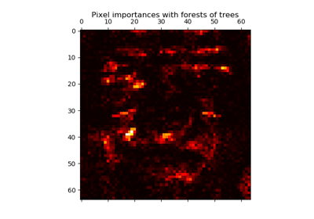

Pixel importances with a parallel forest of trees

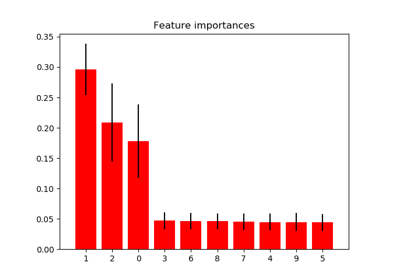

Feature importances with forests of trees

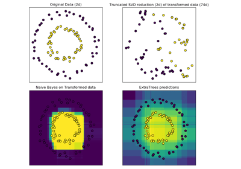

Hashing feature transformation using Totally Random Trees

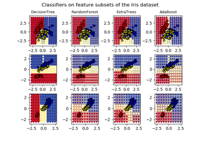

Plot the decision surfaces of ensembles of trees on the iris dataset

© 2007–2018 The scikit-learn developers  
Licensed under the 3-clause BSD License.  
http://scikit-learn.org/stable/modules/generated/sklearn.ensemble.ExtraTreesClassifier.html